# Graphical Exploratory Data Analysis (GEDA)

## Introducción

## Objetivo

Obtener información sobre el contexto y en alcance de la base de datos de consumo de agua.

1. Características de generales de la base.
2. Relación entre alcaldías y consumo de agua.
3. Relación entre el índice de desarrollo, alcaldía y consumo de agua.
4. Análisis de latitud y longitud de acuerdo al Índice de Desarrollo.
5. Número de habitantes y consumo de agua.
6. Análisis de valores faltantes
7. Preguntas

## Características generales de la base

### **71102 observaciones** y **17 variables**.

## Mediciones principales del consumo de agua

- `consumo_total`: Que es el consumo total de acuerdo a los medidores instalados o autorizados por el Sistema de Aguas.
- `comsumo_prom`: Que es un cálculo promedio de consumo de agua que se aplica para cubrir las faltas o fallas en los aparatos de medición.

## Tipos de consumo de agua

- Doméstico: Uso habitacional (`consumo_prom_dom`, `consumo_total_dom`).
- No Doméstico: Uso no doméstico (`consumo_prom_no_dom`, `consumo_total_no_dom`).
- Mixto: uso doméstico y no doméstico (`consumo_total_mixto`, `consumo_prom_mixto`).

## Información de geolocalización

- `alcaldía`: Variable categórica que contiene las 16 alcaldías de la CDMX.
- `colonia`: Variable categórica que contiene 1340 colonias registradas.
- `latitud` y `longitud`: Variables numéricas que representan las coordenadas de los medidores.

## Información temporal

- `bimestre`: que contiene la información de solo tres bimestres.
- `anio`: que es solo tiene la información del año 2019.

## Índice de desarrollo

Información que diferencía territorialmente a la población de la CDMX de acuerdo a su nivel de desarrollo económico (`indice_des`), agregando la información por colonia, los niveles son:

- POPULAR: Niveles de desarrollo más bajos de la Ciudad.
- BAJO: Niveles de desarrollo bajo de la Ciudad.
- MEDIO: Niveles de desarrollo medio de la Ciudad.
- ALTO: Niveles de desarrollo altos de la Ciudad.

## Relación entre alcaldías y consumo de agua

Conteos de

información

por alcaldia.

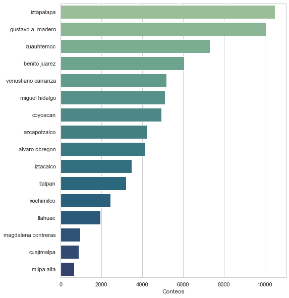

Tipos de

consumo de agua

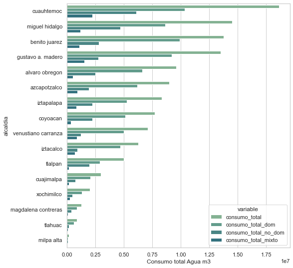

Diferencias entre

consumo doméstico y

consumo no doméstico

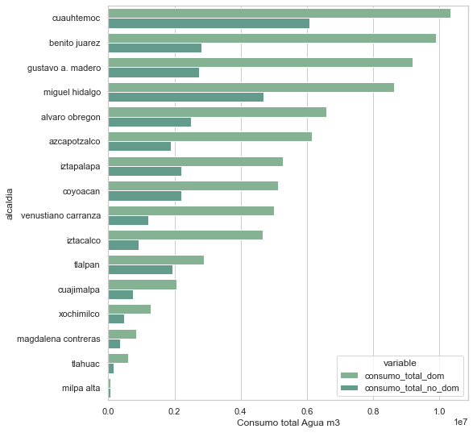

## Relación entre alcaldías, consumo de agua e Índice de Desarrollo

Consumo total de agua por

alcaldía e

Índice de Desarrollo

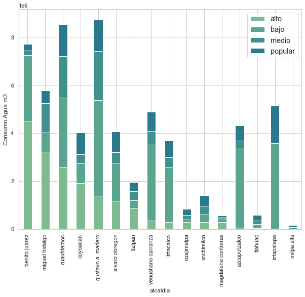

Consumo promedio de agua por

alcaldía e

Índice de Desarrollo

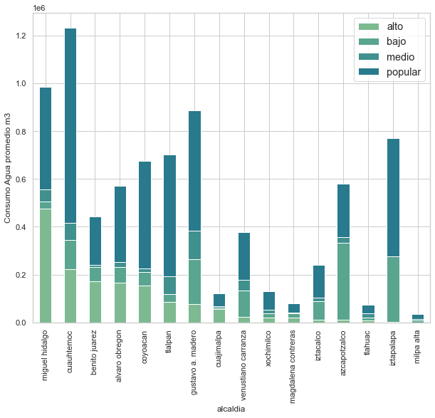

Análisis de

latitud y longitud

de acuerdo al

Índice de Desarrollo

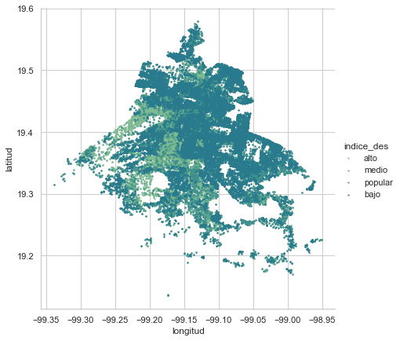

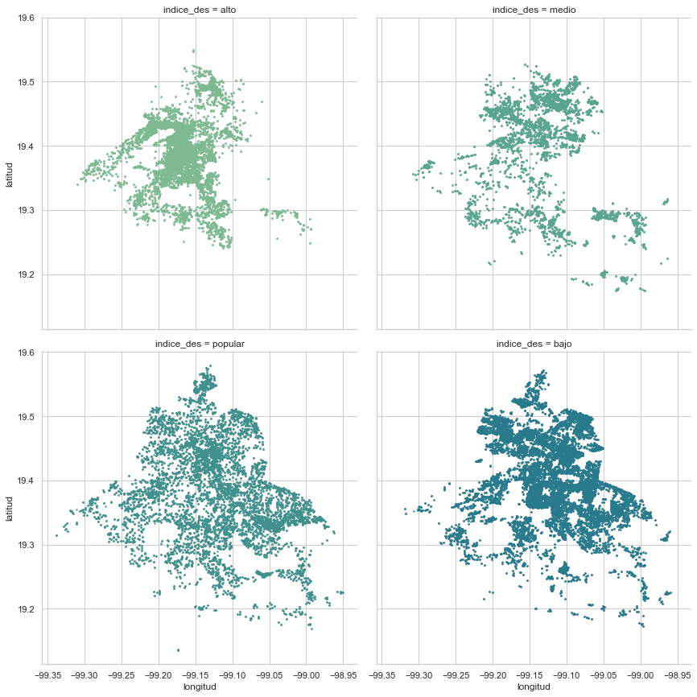

## Número de habitantes y consumo de agua

Habitantes por alcaldía

y consumo de agua doméstico

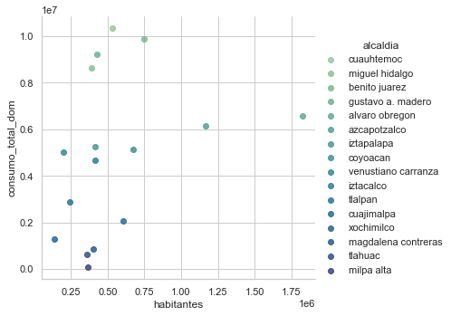

Habitantes por alcaldía

y consumo de agua no doméstico

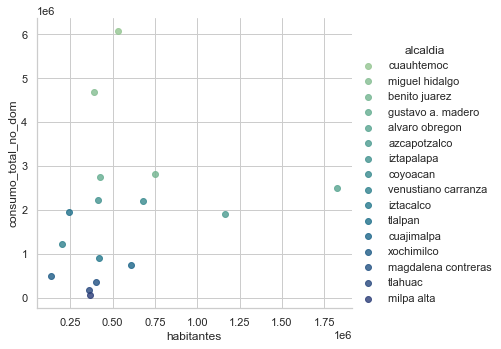

## Análisis de valores faltantes

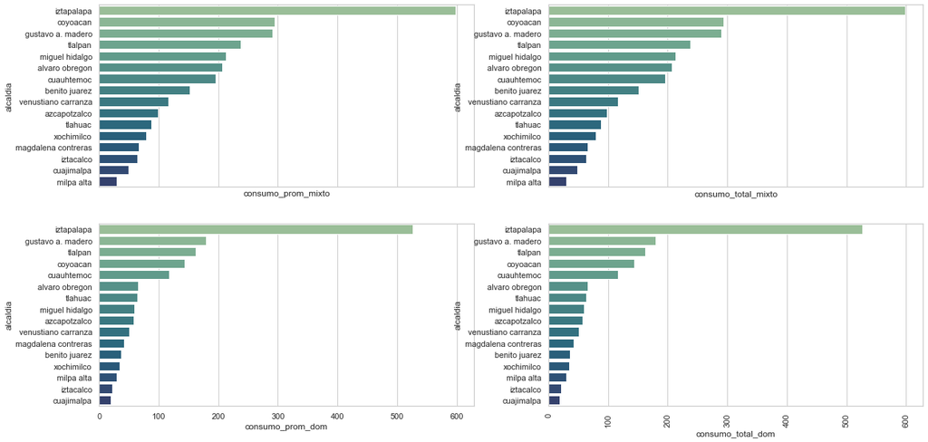

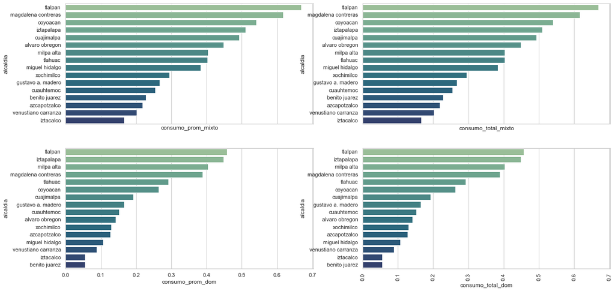